# Unsupervised learning

Mary_Njuguna

2022-06-03

## Problem Statement

Kira Plastinina is a Russian brand that is sold through a defunct chain of retail stores in Russia, Ukraine, Kazakhstan, Belarus, China, Philippines, and Armenia. The brand’s Sales and Marketing team would like to understand their customer’s behavior from data that they have collected over the past year. More specifically, they would like to learn the characteristics of customer groups.

Perform clustering stating insights drawn from your analysis and visualizations. Upon implementation, provide comparisons between the approaches learned this week i.e. K-Means clustering vs Hierarchical clustering highlighting the strengths and limitations of each approach in the context of your analysis.

## Experimental Design

- Importing libraries
- Loading the dataset
- Cleaning the data by checking and dealing with missing values, duplicates, unique values and outliers.
- Performing univariate analysis
- Performing bivariate analysis
- Unsupervised Machine learning
- Conclusion
- Recommendation

## Data Relevance

- The dataset consists of 10 numerical and 8 categorical attributes. The ‘Revenue’ attribute can be used as the class label.
- “Administrative”, “Administrative Duration”, “Informational”, “Informational Duration”, “Product Related” and “Product Related Duration” represents the number of different types of pages visited by the visitor in that session and total time spent in each of these page categories. The values of these features are derived from the URL information of the pages visited by the user and updated in real-time when a user takes an action, e.g. moving from one page to another.
- The “Bounce Rate”, “Exit Rate” and “Page Value” features represent the metrics measured by “Google Analytics” for each page in the e-commerce site.
- The value of the “Bounce Rate” feature for a web page refers to the percentage of visitors who enter the site from that page and then leave (“bounce”) without triggering any other requests to the analytics server during that session.
- The value of the “Exit Rate” feature for a specific web page is calculated as for all pageviews to the page, the percentage that was the last in the session.
- The “Page Value” feature represents the average value for a web page that a user visited before completing an e-commerce transaction.
- The “Special Day” feature indicates the closeness of the site visiting time to a specific special day (e.g. Mother’s Day, Valentine’s Day) in which the sessions are more likely to be finalized with the transaction. The value of this attribute is determined by considering the dynamics of e-commerce such as the duration between the order date and delivery date. For example, for Valentina’s day, this value takes a nonzero value between February 2 and February 12, zero before and after this date unless it is close to another special day, and its maximum value of 1 on February 8. -The dataset also includes the operating system, browser, region, traffic type, visitor type as returning or new visitor, a Boolean value indicating whether the date of the visit is weekend, and month of the year.

## Importing Libraries

```r
library(ggplot2)
library(ggvis)
library(Amelia)
library(tibble)
library(dplyr)
library(ggplot2)
library(Hmisc)
library(reshape2)
library(caret)
library(superml)
library(tidyverse) # data manipulation
library(corrplot)
library(gridExtra)
library(GGally)
library(cluster) # clustering algorithms
library(factoextra) # clustering algorithms & visualization
```

## Loading the dataset

```r
ecommerce <- read.csv("http://bit.ly/EcommerceCustomersDataset")

#loading the dataset as tibble
ecommerce<- as_tibble(ecommerce)
```

## Previewing the dataset

```r
#viewing the top of the dataset
head(ecommerce)
```

```
## # A tibble: 6 × 18
##   Administrative Administrative_D… Informational Informational_D… ProductRelated
##            <int>             <dbl>         <int>            <dbl>          <int>
## 1              0                 0             0                0              1
## 2              0                 0             0                0              2
## 3              0                -1             0               -1              1
## 4              0                 0             0                0              2
## 5              0                 0             0                0             10
## 6              0                 0             0                0             19
## # … with 13 more variables: ProductRelated_Duration <dbl>, BounceRates <dbl>,
## #   ExitRates <dbl>, PageValues <dbl>, SpecialDay <dbl>, Month <chr>,
## #   OperatingSystems <int>, Browser <int>, Region <int>, TrafficType <int>,
## #   VisitorType <chr>, Weekend <lgl>, Revenue <lgl>
```

```r
#Viewing the bottom of the dataset
tail(ecommerce)
```

```
## # A tibble: 6 × 18
##   Administrative Administrative_D… Informational Informational_D… ProductRelated
##            <int>             <dbl>         <int>            <dbl>          <int>
## 1              0                 0             1                0             16
## 2              3               145             0                0             53
## 3              0                 0             0                0              5
## 4              0                 0             0                0              6
## 5              4                75             0                0             15
## 6              0                 0             0                0              3
## # … with 13 more variables: ProductRelated_Duration <dbl>, BounceRates <dbl>,
## #   ExitRates <dbl>, PageValues <dbl>, SpecialDay <dbl>, Month <chr>,
## #   OperatingSystems <int>, Browser <int>, Region <int>, TrafficType <int>,
## #   VisitorType <chr>, Weekend <lgl>, Revenue <lgl>
```

```r
# dimension of ecommerce dataset
dim(ecommerce)
```

```
## [1] 12330    18
```

the dataset has 12330 rows and 18 columns

```r
#checking the variable type of each column
#Abstract(ecommerce)
```

```r
#Listing all the columns
colnames(ecommerce)
```

```
##  [1] "Administrative"          "Administrative_Duration"
##  [3] "Informational"           "Informational_Duration"
##  [5] "ProductRelated"          "ProductRelated_Duration"
##  [7] "BounceRates"             "ExitRates"
##  [9] "PageValues"              "SpecialDay"
## [11] "Month"                   "OperatingSystems"
## [13] "Browser"                 "Region"
## [15] "TrafficType"             "VisitorType"
## [17] "Weekend"                 "Revenue"
```

### Structure of the dataset

```r
#Structure of the dataset
str(ecommerce)
```

```
## tibble [12,330 × 18] (S3: tbl_df/tbl/data.frame)
##  $ Administrative         : int [1:12330] 0 0 0 0 0 0 0 1 0 0 ...
##  $ Administrative_Duration: num [1:12330] 0 0 -1 0 0 0 -1 -1 0 0 ...
##  $ Informational          : int [1:12330] 0 0 0 0 0 0 0 0 0 0 ...
##  $ Informational_Duration : num [1:12330] 0 0 -1 0 0 0 -1 -1 0 0 ...
##  $ ProductRelated         : int [1:12330] 1 2 1 2 10 19 1 1 2 3 ...
##  $ ProductRelated_Duration: num [1:12330] 0 64 -1 2.67 627.5 ...
##  $ BounceRates            : num [1:12330] 0.2 0 0.2 0.05 0.02 ...
##  $ ExitRates              : num [1:12330] 0.2 0.1 0.2 0.14 0.05 ...
##  $ PageValues             : num [1:12330] 0 0 0 0 0 0 0 0 0 0 ...
##  $ SpecialDay             : num [1:12330] 0 0 0 0 0 0 0.4 0 0.8 0.4 ...
##  $ Month                  : chr [1:12330] "Feb" "Feb" "Feb" "Feb" ...
##  $ OperatingSystems       : int [1:12330] 1 2 4 3 3 2 2 1 2 2 ...
##  $ Browser                : int [1:12330] 1 2 1 2 3 2 4 2 2 4 ...
##  $ Region                 : int [1:12330] 1 1 9 2 1 1 3 1 2 1 ...
##  $ TrafficType            : int [1:12330] 1 2 3 4 4 3 3 5 3 2 ...
##  $ VisitorType            : chr [1:12330] "Returning_Visitor" "Returning_Visitor" "Returning_Visitor" "Returning_Visitor" ...
##  $ Weekend                : logi [1:12330] FALSE FALSE FALSE FALSE TRUE FALSE ...
##  $ Revenue                : logi [1:12330] FALSE FALSE FALSE FALSE FALSE FALSE ...
```

```r
#Returning the numeric columns
ecommerce_num<- select_if(ecommerce, is.numeric)
colnames(ecommerce_num)
```

```
##  [1] "Administrative"          "Administrative_Duration"
##  [3] "Informational"           "Informational_Duration"
##  [5] "ProductRelated"          "ProductRelated_Duration"
##  [7] "BounceRates"             "ExitRates"
##  [9] "PageValues"              "SpecialDay"
## [11] "OperatingSystems"        "Browser"
## [13] "Region"                  "TrafficType"
```

## Completeness

```r
#Checkung for the total  null values
sum(is.na(ecommerce))
```

```
## [1] 112
```

There are 112 missing values

```r
#Checking the distribution of null values to each column
colSums(is.na(ecommerce))
```

```
##          Administrative Administrative_Duration           Informational
##                      14                      14                      14
##  Informational_Duration          ProductRelated ProductRelated_Duration
##                      14                      14                      14
##             BounceRates               ExitRates              PageValues
##                      14                      14                       0
##              SpecialDay                   Month        OperatingSystems
##                       0                       0                       0
##                 Browser                  Region             TrafficType
##                       0                       0                       0
##             VisitorType                 Weekend                 Revenue
##                       0                       0                       0
```

the columns that has missing values are: - Administrative - Administrative_duration - Informational - Informational duration - ProductRelated - ProductRelated_Duration - BounceRates - ExitRates Each of these columns has 14 missing values.

```r
#Checking the percentage  of the missing values
missing_percentage<- function(x){sum(is.na(x))/length(x)*100}
apply(ecommerce,2,missing_percentage)
```

```
##          Administrative Administrative_Duration           Informational
##               0.1135442               0.1135442               0.1135442
##  Informational_Duration          ProductRelated ProductRelated_Duration
##               0.1135442               0.1135442               0.1135442
##             BounceRates               ExitRates              PageValues
##               0.1135442               0.1135442               0.0000000
##              SpecialDay                   Month        OperatingSystems
##               0.0000000               0.0000000               0.0000000
##                 Browser                  Region             TrafficType
##               0.0000000               0.0000000               0.0000000
##             VisitorType                 Weekend                 Revenue
##               0.0000000               0.0000000               0.0000000
```

since the percentage is less than 50% of the dataset, they will be dropped

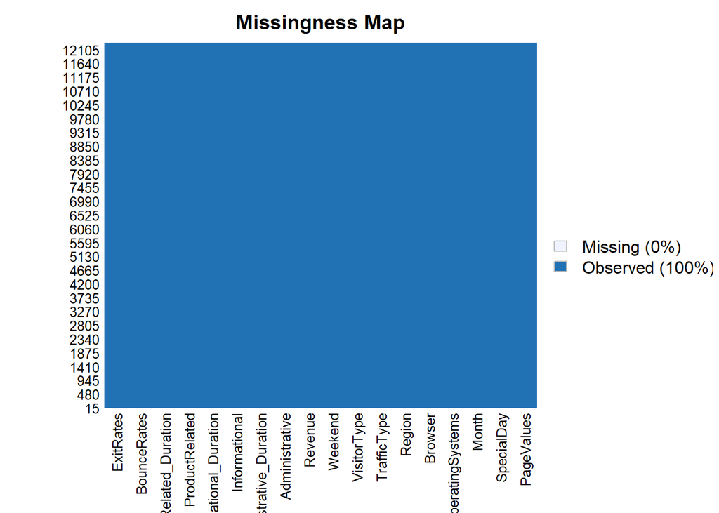

```r
#visualizing the missing values using missmap
missmap(ecommerce)
```

### Dropping the missing values

```r
#dropping missing values using omit
ecommerce<- na.omit(ecommerce)

#Rechecking the missing values
sum(is.na(ecommerce))
```

```
## [1] 0
```

## Consistency

### checking for duplicates

```r
#Checking if there is any duplicate values
anyDuplicated(ecommerce)
```

```
## [1] 159
```

```r
#Dropping duplicates
ecommerce<- ecommerce[!duplicated(ecommerce),]

#Rechecking the duplicate values
anyDuplicated(ecommerce)
```

```
## [1] 0
```

## Accuracy

```r
#Converting categorical variables into factors
ecommerce$Month<- factor(ecommerce$Month)
ecommerce$OperatingSystems<- factor(ecommerce$OperatingSystems)
ecommerce$Browser<- factor(ecommerce$Browser)
ecommerce$Region<- factor(ecommerce$Region)
ecommerce$TrafficType<- factor(ecommerce$TrafficType)
ecommerce$VisitorType<- factor(ecommerce$VisitorType)
ecommerce$Weekend<- factor(ecommerce$Weekend)
ecommerce$Revenue<- factor(ecommerce$Revenue)
```

### Evaluating the unique values

```r
unique(ecommerce$Weekend)
```

```
## [1] FALSE TRUE
## Levels: FALSE TRUE
```

### Visualizing the outliers

###Extracting numeric variables

```r
#Extracting numeric values unorder to determine unique values and outliers
numeric_values<- unlist(lapply(ecommerce, is.numeric))

numeric_cols<-ecommerce[,numeric_values]
#Printing the numeric columns
head(numeric_cols)
```

```
## # A tibble: 6 × 10
##   Administrative Administrative_D… Informational Informational_D… ProductRelated
##            <int>             <dbl>         <int>            <dbl>          <int>
## 1              0                 0             0                0              1
## 2              0                 0             0                0              2
## 3              0                -1             0               -1              1
## 4              0                 0             0                0              2
## 5              0                 0             0                0             10
## 6              0                 0             0                0             19
## # … with 5 more variables: ProductRelated_Duration <dbl>, BounceRates <dbl>,
## #   ExitRates <dbl>, PageValues <dbl>, SpecialDay <dbl>
```

```r
#Function to check the outliers
outlier_vals<- function(x){
  out<- boxplot.stats(x)$out
  return((length(out)/12199)*100)
}
#Evaluating outliers per column
sapply(ecommerce[,c(1:9)],outlier_vals)
```

```
##          Administrative Administrative_Duration           Informational
##                3.311747                9.402410               21.559144
##  Informational_Duration          ProductRelated ProductRelated_Duration
##               19.977047                8.254775                7.795721
##             BounceRates               ExitRates              PageValues
##               11.730470               10.877941               22.378884
```

Most outlier are found on informational, informational duration, bounce rates, exit rates and page values. ###Visualizing the outliers

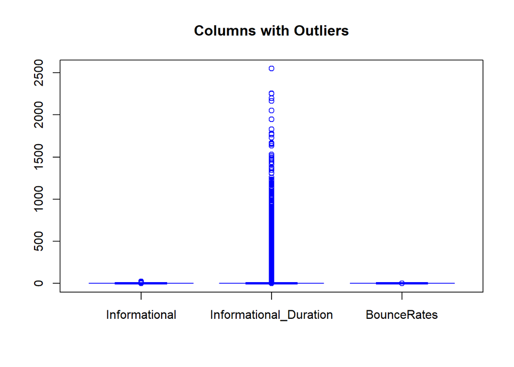

```r
boxplot(ecommerce$Informational,ecommerce$Informational_Duration,ecommerce$BounceRates,
        main="Columns with Outliers",names = c("Informational","Informational_Duration","BounceRates"),border = "Blue",notch = TRUE)
```

## Univariate Analysis

- Determining the cenral tendancy of the numeric variables that is mean, mode and median and also measure of dispersion which includes minimum, maximum, range,quantiles, variance and standard deviation.

```r
#Checking the summary statistics which returns the central of tendancy and measure of dispersion

summary(ecommerce)
```

```
##  Administrative  Administrative_Duration Informational
##  Min.   : 0.00   Min.   :  -1.00         Min.   : 0.0000
##  1st Qu.: 0.00   1st Qu.:   0.00         1st Qu.: 0.0000
##  Median : 1.00   Median :   9.00         Median : 0.0000
##  Mean   : 2.34   Mean   :  81.68         Mean   : 0.5088
##  3rd Qu.: 4.00   3rd Qu.:  94.75         3rd Qu.: 0.0000
##  Max.   :27.00   Max.   :3398.75         Max.   :24.0000
##
##  Informational_Duration ProductRelated   ProductRelated_Duration
##  Min.   :  -1.00        Min.   :  0.00   Min.   :   -1.0
##  1st Qu.:   0.00        1st Qu.:  8.00   1st Qu.:  193.6
##  Median :   0.00        Median : 18.00   Median :  609.5
##  Mean   :  34.84        Mean   : 32.06   Mean   : 1207.5
##  3rd Qu.:   0.00        3rd Qu.: 38.00   3rd Qu.: 1477.6
##  Max.   :2549.38        Max.   :705.00   Max.   :63973.5
##
##   BounceRates        ExitRates         PageValues        SpecialDay
##  Min.   :0.00000   Min.   :0.00000   Min.   :  0.000   Min.   :0.00000
##  1st Qu.:0.00000   1st Qu.:0.01422   1st Qu.:  0.000   1st Qu.:0.00000
##  Median :0.00293   Median :0.02500   Median :  0.000   Median :0.00000
##  Mean   :0.02045   Mean   :0.04150   Mean   :  5.952   Mean   :0.06197
##  3rd Qu.:0.01667   3rd Qu.:0.04848   3rd Qu.:  0.000   3rd Qu.:0.00000
##  Max.   :0.20000   Max.   :0.20000   Max.   :361.764   Max.   :1.00000
##
##      Month      OperatingSystems    Browser         Region      TrafficType
##  May    :3328   2      :6536     2      :7878   1      :4711   2      :3907
##  Nov    :2983   1      :2548     1      :2426   3      :2382   1      :2383
##  Mar    :1853   3      :2530     4      : 730   4      :1168   3      :2017
##  Dec    :1706   4      : 478     5      : 466   2      :1127   4      :1066
##  Oct    : 549   8      :  75     6      : 174   6      : 800   13     : 728
##  Sep    : 448   6      :  19     10     : 163   7      : 758   10     : 450
##  (Other):1332   (Other):  13     (Other): 362   (Other):1253   (Other):1648
##             VisitorType     Weekend      Revenue
##  New_Visitor      : 1693   FALSE:9343   FALSE:10291
##  Other            :   81   TRUE :2856   TRUE : 1908
##  Returning_Visitor:10425
##
##
##
##
```

```r
#Description of the numerical variables
describe(ecommerce)
```

```
## ecommerce
##
##  18  Variables      12199  Observations
## --------------------------------------------------------------------------------
## Administrative
##        n  missing distinct     Info     Mean      Gmd      .05      .10
##    12199        0       27    0.898     2.34    3.193        0        0
##      .25      .50      .75      .90      .95
##        0        1        4        7        9
##
## lowest :  0  1  2  3  4, highest: 22 23 24 26 27
## --------------------------------------------------------------------------------
## Administrative_Duration
##        n  missing distinct     Info     Mean      Gmd      .05      .10
##    12199        0     3336    0.896    81.68    125.8     0.00     0.00
##      .25      .50      .75      .90      .95
##     0.00     9.00    94.75   227.05   352.23
##
## lowest :   -1.000000    0.000000    1.333333    2.000000    3.000000
## highest: 2407.423810 2629.253968 2657.318056 2720.500000 3398.750000
## --------------------------------------------------------------------------------
## Informational
##        n  missing distinct     Info     Mean      Gmd      .05      .10
##    12199        0       17    0.516   0.5088   0.8763        0        0
##      .25      .50      .75      .90      .95
##        0        0        0        2        3
##
## lowest :  0  1  2  3  4, highest: 12 13 14 16 24
##
## Value          0     1     2     3     4     5     6     7     8     9    10
## Frequency   9569  1041   727   380   222    99    78    36    14    15     7
## Proportion 0.784 0.085 0.060 0.031 0.018 0.008 0.006 0.003 0.001 0.001 0.001
##
## Value         11    12    13    14    16    24
## Frequency      1     5     1     2     1     1
## Proportion 0.000 0.000 0.000 0.000 0.000 0.000
## --------------------------------------------------------------------------------
## Informational_Duration
##        n  missing distinct     Info     Mean      Gmd      .05      .10
##    12199        0     1259    0.488    34.84    64.71        0        0
```

[output cut: 127 more lines]

```
##        n  missing distinct
##    12199        0        2
##
## Value      FALSE  TRUE
## Frequency   9343  2856
## Proportion 0.766 0.234
## --------------------------------------------------------------------------------
## Revenue
##        n  missing distinct
##    12199        0        2
##
## Value      FALSE  TRUE
## Frequency  10291  1908
## Proportion 0.844 0.156
## --------------------------------------------------------------------------------
```

### Mode

Administrative

```r
#Value that appeared most frequently in age
getmode<-function(v){
  uniqv<-unique(v)
  uniqv[which.max(tabulate(match(v,uniqv)))]
}
Administrative.mode<-getmode(ecommerce$Administrative)
Administrative.mode
```

```
## [1] 0
```

Administrative_Duration

```r
#Value that appeared most frequently in age
getmode<-function(v){
  uniqv<-unique(v)
  uniqv[which.max(tabulate(match(v,uniqv)))]
}
Administrative_Duration.mode<-getmode(ecommerce$Administrative_Duration)
Administrative_Duration.mode
```

```
## [1] 0
```

Informational

```r
#Value that appeared most frequently in age
getmode<-function(v){
  uniqv<-unique(v)
  uniqv[which.max(tabulate(match(v,uniqv)))]
}
Informational.mode<-getmode(ecommerce$Informational)
Informational.mode
```

```
## [1] 0
```

Informational_Duration

```r
#Value that appeared most frequently in age
getmode<-function(v){
  uniqv<-unique(v)
  uniqv[which.max(tabulate(match(v,uniqv)))]
}
Informational_Duration.mode<-getmode(ecommerce$Informational_Duration)
Informational_Duration.mode
```

```
## [1] 0
```

ProductRelated

```r
#Value that appeared most frequently in age
getmode<-function(v){
  uniqv<-unique(v)
  uniqv[which.max(tabulate(match(v,uniqv)))]
}
ProductRelated.mode<-getmode(ecommerce$ProductRelated)
ProductRelated.mode
```

```
## [1] 1
```

ProductRelated_Duration

```r
#Value that appeared most frequently in age
getmode<-function(v){
  uniqv<-unique(v)
  uniqv[which.max(tabulate(match(v,uniqv)))]
}
ProductRelated_Duration.mode<-getmode(ecommerce$ProductRelated_Duration)
ProductRelated_Duration.mode
```

```
## [1] 0
```

OperatingSystems

```r
#Value that appeared most frequently in age
getmode<-function(v){
  uniqv<-unique(v)
  uniqv[which.max(tabulate(match(v,uniqv)))]
}
OperatingSystems.mode<-getmode(ecommerce$OperatingSystems)
OperatingSystems.mode
```

```
## [1] 2
## Levels: 1 2 3 4 5 6 7 8
```

Browser

```r
#Value that appeared most frequently in age
getmode<-function(v){
  uniqv<-unique(v)
  uniqv[which.max(tabulate(match(v,uniqv)))]
}
Browser.mode<-getmode(ecommerce$Browser)
Browser.mode
```

```
## [1] 2
## Levels: 1 2 3 4 5 6 7 8 9 10 11 12 13
```

Region

```r
#Value that appeared most frequently in age
getmode<-function(v){
  uniqv<-unique(v)
  uniqv[which.max(tabulate(match(v,uniqv)))]
}
Region.mode<-getmode(ecommerce$Region)
Region.mode
```

```
## [1] 1
## Levels: 1 2 3 4 5 6 7 8 9
```

## NUmeric Variables

### Plotting Histograms

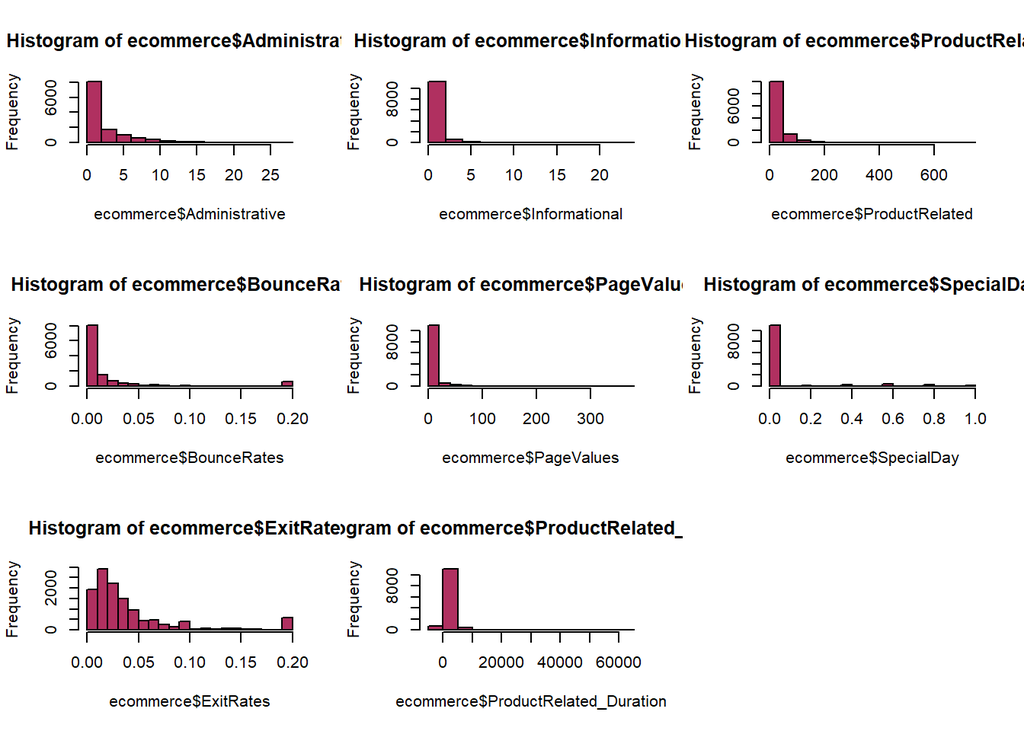

```r
par(mfrow = c(3,3))
hist(ecommerce$Administrative, col = "Maroon")
hist(ecommerce$Informational,col = "Maroon")
hist(ecommerce$ProductRelated,col = "Maroon")
hist(ecommerce$BounceRates,col = "Maroon")
hist(ecommerce$PageValues, col = "Maroon")
hist(ecommerce$SpecialDay,col = "Maroon")
hist(ecommerce$ExitRates,col = "Maroon")
hist(ecommerce$ProductRelated_Duration,col = "Maroon")
```

## Categorical Variables

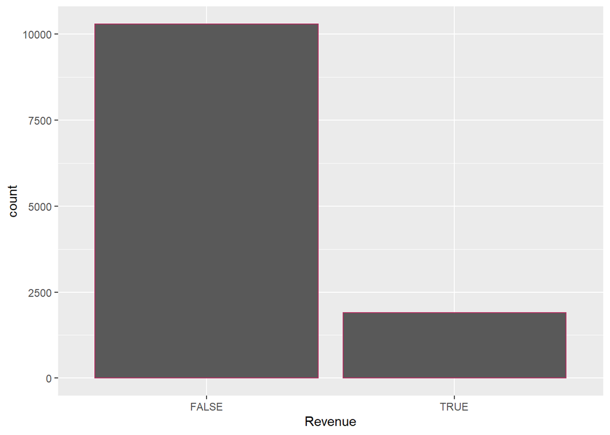

```r
#Revenue
ggplot(ecommerce, aes(Revenue))+ geom_bar(col="Maroon")
```

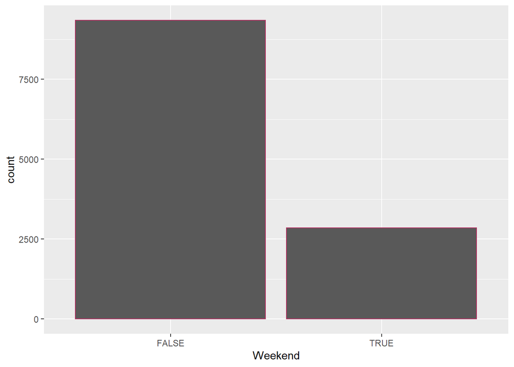

```r
#Weekend
ggplot(ecommerce, aes(Weekend))+ geom_bar(col="Maroon")
```

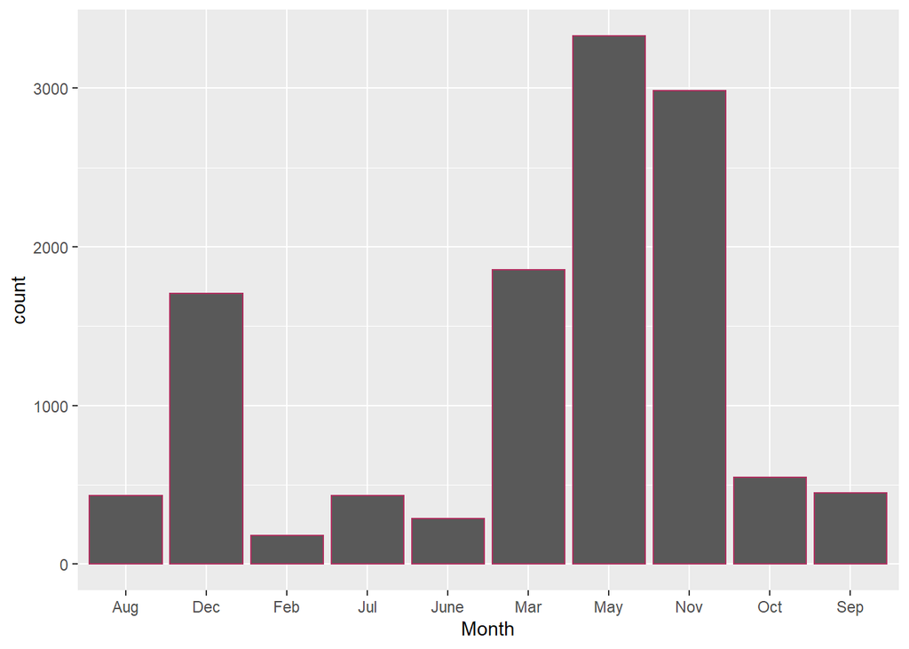

```r
#Month
ggplot(ecommerce, aes(Month))+ geom_bar(col="Maroon")
```

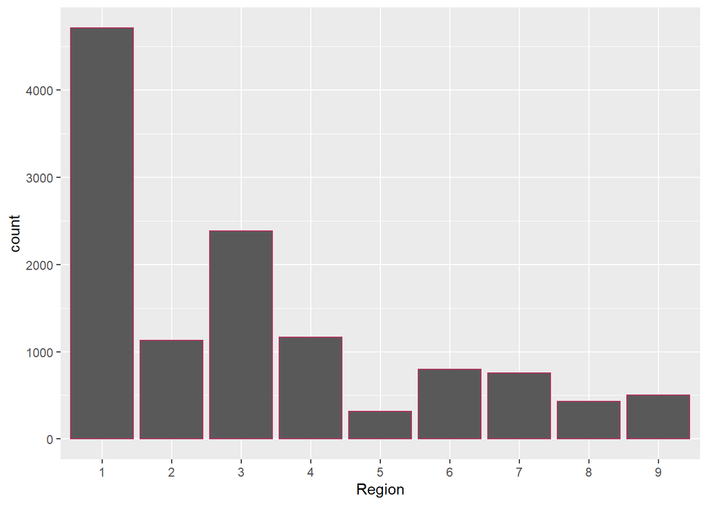

```r
#Region
ggplot(ecommerce, aes(Region))+ geom_bar(col="Maroon")
```

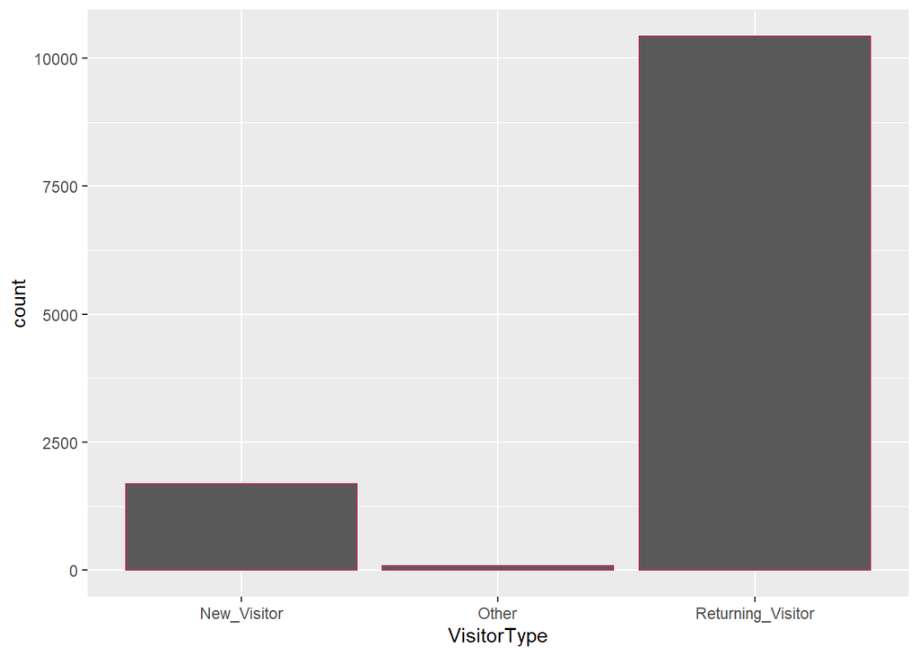

```r
#VisitorType
ggplot(ecommerce, aes(VisitorType))+ geom_bar(col="Maroon")
```

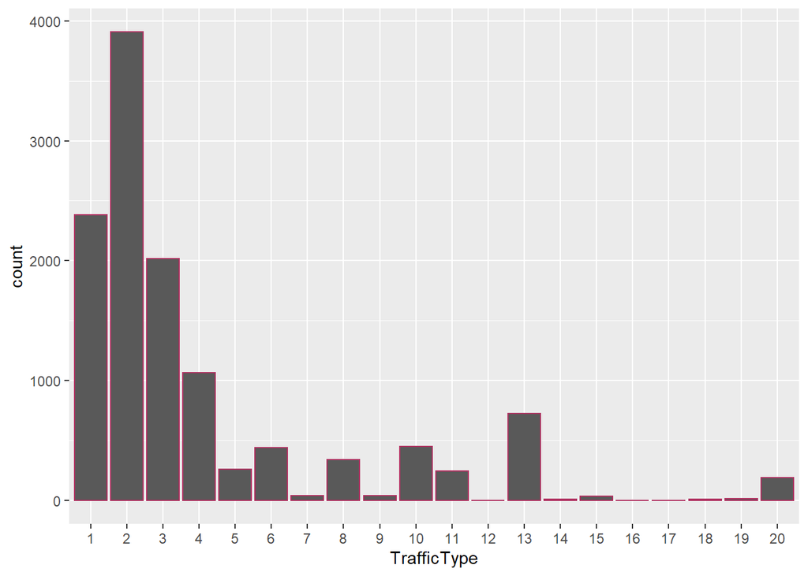

```r
#TrafficType
ggplot(ecommerce, aes(TrafficType))+ geom_bar(col="Maroon")
```

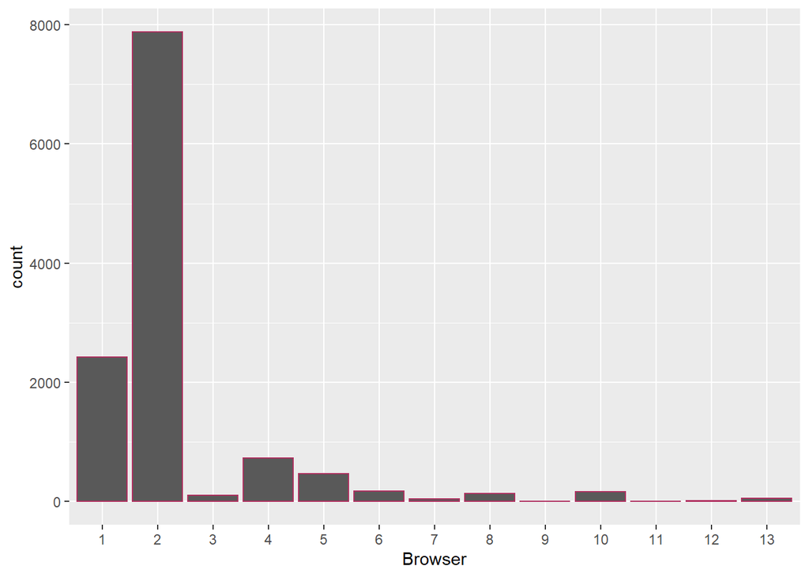

```r
#Browser
ggplot(ecommerce, aes(Browser))+ geom_bar(col="Maroon")
```

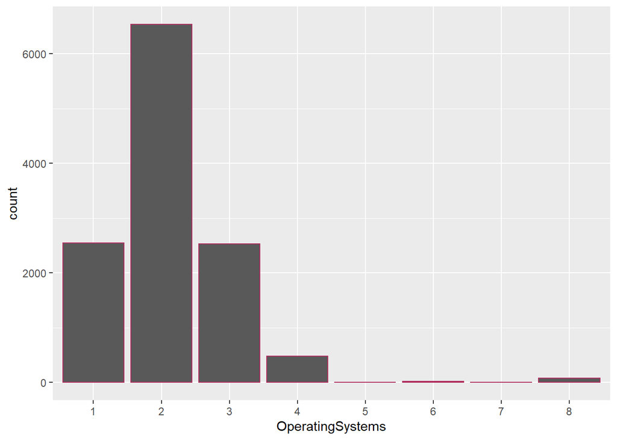

```r
#Operating System
ggplot(ecommerce, aes(OperatingSystems))+ geom_bar(col="Maroon")
```

```r
colnames(ecommerce_num)
```

```
##  [1] "Administrative"          "Administrative_Duration"
##  [3] "Informational"           "Informational_Duration"
##  [5] "ProductRelated"          "ProductRelated_Duration"
##  [7] "BounceRates"             "ExitRates"
##  [9] "PageValues"              "SpecialDay"
## [11] "OperatingSystems"        "Browser"
## [13] "Region"                  "TrafficType"
```

## Bivariate Analysis

### Cavariance between variables

### Administrative

```r
# Assigning the Administrative column to the variable Administrative
Administrative <- ecommerce$Administrative
# Assigning the Revenue column to the variable waiting
PageValues<- ecommerce$PageValues
# Using the cov() function to determine the covariance
cov(Administrative, PageValues)
```

```
## [1] 6.023282
```

```r
# Assigning the Administrative column to the variable Administrative
Administrative <- ecommerce$Administrative
# Assigning the ExitRates column to the variable waiting
BounceRates<- ecommerce$BounceRates
# Using the cov() function to determine the covariance
cov(Administrative,BounceRates)
```

```
## [1] -0.03231259
```

```r
# Assigning the Administrative column to the variable Administrative
Administrative <- ecommerce$Administrative
# Assigning the ExitRates column to the variable waiting
ExitRates<- ecommerce$ExitRates
# Using the cov() function to determine the covariance
cov(Administrative,ExitRates)
```

```
## [1] -0.04794942
```

```r
# Assigning the Informational_Duration column to the variable Administrative
Administrative <- ecommerce$Administrative
# Assigning the Revenue column to the variable waiting
SpecialDay<- ecommerce$SpecialDay
# Using the cov() function to determine the covariance
cov(Administrative, SpecialDay)
```

```
## [1] -0.06457297
```

### Administrative_Duration

```r
# Assigning the Administrative_Duration column to the variable Administrative_Duration
Administrative_Duration <- ecommerce$Administrative_Duration
# Assigning the Informational_Durationcolumn to the variable waiting
BounceRates<- ecommerce$BounceRates
# Using the cov() function to determine the covariance
cov(Administrative_Duration, BounceRates)
```

```
## [1] -1.106938
```

```r
# Assigning the Administrative_Duration column to the variable Administrative_Duration
Administrative_Duration <- Administrative_Duration
# Assigning the ExitRates column to the variable waiting
ExitRates<- ecommerce$ExitRates
# Using the cov() function to determine the covariance
cov(Administrative_Duration,ExitRates)
```

```
## [1] -1.658656
```

```r
# Assigning the Administrative_Duration column to the variable Administrative_Duration
Administrative_Duration <- ecommerce$Administrative_Duration
# Assigning the Revenue column to the variable waiting
PageValues<- ecommerce$PageValues
# Using the cov() function to determine the covariance
cov(Administrative_Duration, PageValues)
```

```
## [1] 219.1684
```

```r
# Assigning the Informational_Duration column to the variable Administrative_Duration
Administrative_Duration <- ecommerce$Administrative_Duration
# Assigning the Revenue column to the variable waiting
SpecialDay<- ecommerce$SpecialDay
# Using the cov() function to determine the covariance
cov(Administrative_Duration, SpecialDay)
```

```
## [1] -2.649741
```

### Informational

```r
# Assigning the Informational column to the variable Informational
Informational <- ecommerce$Informational
# Assigning the ExitRates to the variable waiting
ExitRates<- ecommerce$ExitRates
# Using the cov() function to determine the covariance
cov(Informational, ExitRates)
```

```
## [1] -0.009414909
```

```r
# Assigning the Informational column to the variable Informational
Informational <- ecommerce$Informational
# Assigning the Revenue column to the variable waiting
PageValues<- ecommerce$PageValues
# Using the cov() function to determine the covariance
cov(Informational, PageValues)
```

```
## [1] 1.128072
```

```r
# Assigning the Informational_Duration column to the variable Informational
Informational <- ecommerce$Informational
# Assigning the Informational_Durationcolumn to the variable waiting
BounceRates<- ecommerce$BounceRates
# Using the cov() function to determine the covariance
cov(Informational, BounceRates)
```

```
## [1] -0.006343127
```

```r
# Assigning the Informational_Duration column to the variable Informational
Informational <- ecommerce$Informational
# Assigning the Revenue column to the variable waiting
SpecialDay<- ecommerce$SpecialDay
# Using the cov() function to determine the covariance
cov(Informational, SpecialDay)
```

```
## [1] -0.01258092
```

### Informational_Duration

```r
# Assigning the Informational_Duration column to the variable Informational_Duration
Informational_Duration <- ecommerce$Informational_Duration
# Assigning the Informational_Durationcolumn to the variable waiting
BounceRates<- ecommerce$BounceRates
# Using the cov() function to determine the covariance
cov(Informational_Duration, BounceRates)
```

```
## [1] -0.4506041
```

```r
# Assigning the Informational_Duration column to the variable Informational_Duration
Informational_Duration <- ecommerce$Informational_Duration
# Assigning the ExitRates to the variable waiting
ExitRates<- ecommerce$ExitRates
# Using the cov() function to determine the covariance
cov(Informational_Duration, ExitRates)
```

```
## [1] -0.6733911
```

```r
# Assigning the Informational_Duration column to the variable Informational_Duration
Informational_Duration <- ecommerce$Informational_Duration
# Assigning the Revenue column to the variable waiting
PageValues<- ecommerce$PageValues
# Using the cov() function to determine the covariance
cov(Informational_Duration, PageValues)
```

```
## [1] 79.34843
```

```r
# Assigning the Informational_Duration column to the variable Informational_Duration
Informational_Duration <- ecommerce$Informational_Duration
# Assigning the Revenue column to the variable waiting
SpecialDay<- ecommerce$SpecialDay
# Using the cov() function to determine the covariance
cov(Informational_Duration, SpecialDay)
```

```
## [1] -0.8840522
```

### ProductRelated

```r
# Assigning the ProductRelated column to the variable ProductRelated
ProductRelated <- ecommerce$ProductRelated
# Assigning the Informational_Durationcolumn to the variable waiting
BounceRates<- ecommerce$BounceRates
# Using the cov() function to determine the covariance
cov(Administrative_Duration, BounceRates)
```

```
## [1] -1.106938
```

```r
# Assigning the ProductRelated column to the variable ProductRelated
ProductRelated <- ecommerce$ProductRelated
# Assigning the Revenue column to the variable waiting
SpecialDay<- ecommerce$SpecialDay
# Using the cov() function to determine the covariance
cov(ProductRelated, SpecialDay)
```

```
## [1] -0.2309712
```

```r
# Assigning the ProductRelated column to the variable ProductRelated
ProductRelated <- ecommerce$ProductRelated
# Assigning the Revenue column to the variable waiting
PageValues<- ecommerce$PageValues
# Using the cov() function to determine the covariance
cov(ProductRelated, PageValues)
```

```
## [1] 45.03245
```

```r
# Assigning the ProductRelated column to the variable ProductRelated
ProductRelated <- ecommerce$ProductRelated
# Assigning the ExitRates to the variable waiting
ExitRates<- ecommerce$ExitRates
# Using the cov() function to determine the covariance
cov(ProductRelated, ExitRates)
```

```
## [1] -0.590259
```

### ProductRelated_Duration

```r
# Assigning the ProductRelated_Duration column to the variable ProductRelated_Duration
ProductRelated_Duration <- ecommerce$ProductRelated_Duration
# Assigning the Informational_Durationcolumn to the variable waiting
BounceRates<- ecommerce$BounceRates
# Using the cov() function to determine the covariance
cov(ProductRelated_Duration, BounceRates)
```

```
## [1] -15.20023
```

```r
# Assigning the ProductRelated_Duration column to the variable ProductRelated_Duration
ProductRelated_Duration <- ecommerce$ProductRelated_Duration
# Assigning the Revenue column to the variable waiting
SpecialDay<- ecommerce$SpecialDay
# Using the cov() function to determine the covariance
cov(ProductRelated_Duration, SpecialDay)
```

```
## [1] -14.6511
```

```r
# Assigning the ProductRelated_Duration column to the variable ProductRelated_Duration
ProductRelated_Duration <- ecommerce$ProductRelated_Duration
# Assigning the Revenue column to the variable waiting
PageValues<- ecommerce$PageValues
# Using the cov() function to determine the covariance
cov(ProductRelated_Duration, PageValues)
```

```
## [1] 1821.193
```

```r
# Assigning the ProductRelated_Duration column to the variable ProductRelated_Duration
ProductRelated_Duration <- ecommerce$ProductRelated_Duration
# Assigning the ExitRates to the variable waiting
ExitRates<- ecommerce$ExitRates
# Using the cov() function to determine the covariance
cov(ProductRelated_Duration, ExitRates)
```

```
## [1] -21.7835
```

## Correlation

```r
#Extracting numeric values in order to get correlation and correlation matrix
ecommerce_num<- unlist(lapply(ecommerce, is.numeric))

ecommerce_num<-ecommerce[,ecommerce_num]
#Printing the numeric columns
colnames(ecommerce_num)
```

```
##  [1] "Administrative"          "Administrative_Duration"
##  [3] "Informational"           "Informational_Duration"
##  [5] "ProductRelated"          "ProductRelated_Duration"
##  [7] "BounceRates"             "ExitRates"
##  [9] "PageValues"              "SpecialDay"
```

```r
#Function to determine correlation
#cormat is the matrix of the correlation coefficients
#pmat is the matrix of the correlation p-values
flattenCorrMatrix <- function(cormat, pmat){
  ut<- upper.tri(cormat)
  data.frame(
    row = rownames(cormat)[row(cormat)[ut]],
    column = rownames(cormat)[col(cormat[ut])],
    cor =(cormat)[ut],
    p= pmat[ut]
  )
}
#Correlation
corr<-rcorr(as.matrix(ecommerce_num))
corr
```

```
##                         Administrative Administrative_Duration Informational
## Administrative                    1.00                    0.60          0.38
## Administrative_Duration           0.60                    1.00          0.30
## Informational                     0.38                    0.30          1.00
## Informational_Duration            0.25                    0.24          0.62
## ProductRelated                    0.43                    0.29          0.37
## ProductRelated_Duration           0.37                    0.35          0.39
## BounceRates                      -0.21                   -0.14         -0.11
## ExitRates                        -0.31                   -0.20         -0.16
## PageValues                        0.10                    0.07          0.05
## SpecialDay                       -0.10                   -0.07         -0.05
##                         Informational_Duration ProductRelated
## Administrative                            0.25           0.43
## Administrative_Duration                   0.24           0.29
## Informational                             0.62           0.37
## Informational_Duration                    1.00           0.28
## ProductRelated                            0.28           1.00
## ProductRelated_Duration                   0.35           0.86
## BounceRates                              -0.07          -0.19
## ExitRates                                -0.10          -0.29
## PageValues                                0.03           0.05
## SpecialDay                               -0.03          -0.03
##                         ProductRelated_Duration BounceRates ExitRates
## Administrative                             0.37       -0.21     -0.31
## Administrative_Duration                    0.35       -0.14     -0.20
## Informational                              0.39       -0.11     -0.16
## Informational_Duration                     0.35       -0.07     -0.10
## ProductRelated                             0.86       -0.19     -0.29
## ProductRelated_Duration                    1.00       -0.17     -0.25
## BounceRates                               -0.17        1.00      0.90
## ExitRates                                 -0.25        0.90      1.00
## PageValues                                 0.05       -0.12     -0.17
## SpecialDay                                -0.04        0.09      0.12
##                         PageValues SpecialDay
## Administrative                0.10      -0.10
## Administrative_Duration       0.07      -0.07
## Informational                 0.05      -0.05
## Informational_Duration        0.03      -0.03
## ProductRelated                0.05      -0.03
## ProductRelated_Duration       0.05      -0.04
```

[output cut: 38 more lines]

```
## BounceRates             0.0000                              0.0000
## ExitRates               0.0000                  0.0000
## PageValues              0.0000                  0.0000      0.0000
## SpecialDay              0.0000                  0.0000      0.0000
##                         PageValues SpecialDay
## Administrative          0.0000     0.0000
## Administrative_Duration 0.0000     0.0000
## Informational           0.0000     0.0000
## Informational_Duration  0.0009     0.0005
## ProductRelated          0.0000     0.0042
## ProductRelated_Duration 0.0000     0.0000
## BounceRates             0.0000     0.0000
## ExitRates               0.0000     0.0000
## PageValues                         0.0000
## SpecialDay              0.0000
```

### Plotting Correlation

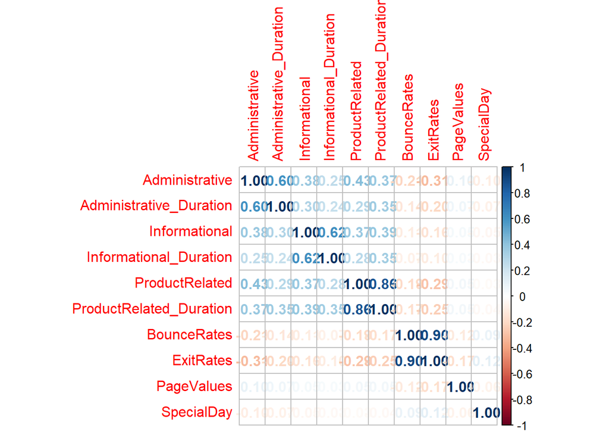

```r
library(corrplot)
corr<-corrplot(corr=cor(ecommerce[, c(1:10)]), method = "number")
```

## Plotting

The relationship between different variables with Label(Revenue)

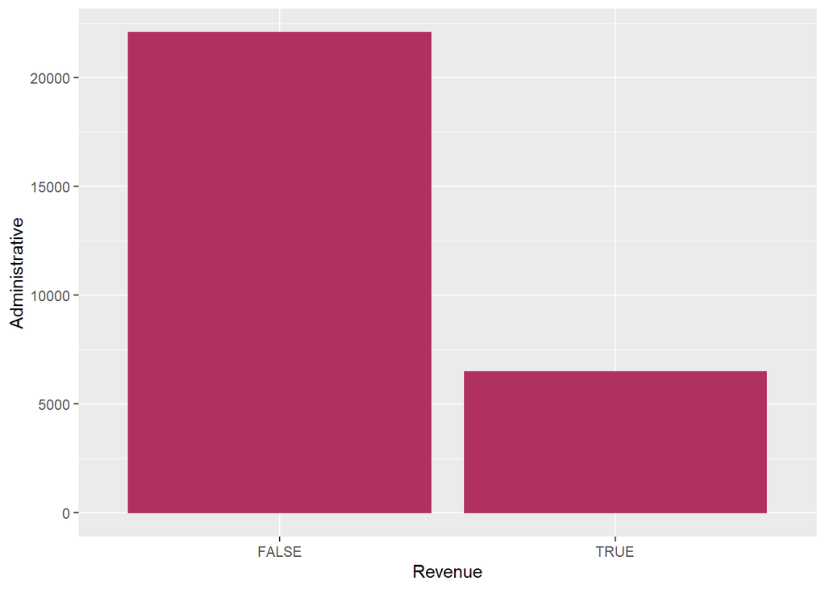

```r
#Bar plot between Revenue and Administrative

ggplot(ecommerce, aes(Revenue,Administrative )) +
   geom_bar(stat = 'identity',col = "Maroon")+ labs(y="Administrative",x="Revenue")
```

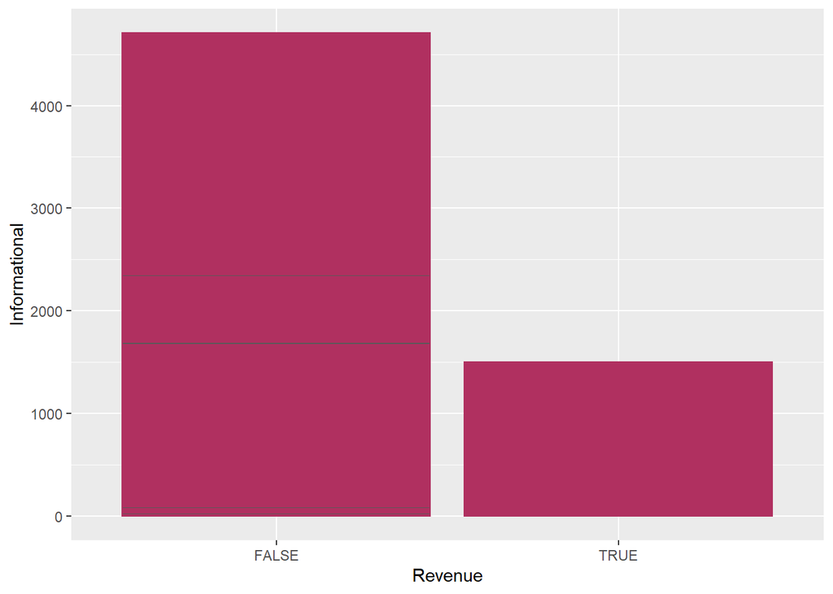

```r
#Bar plot between Revenue and Informational

ggplot(ecommerce, aes(Revenue,Informational )) +
   geom_bar(stat = 'identity',col = "Maroon")+ labs(y="Informational",x="Revenue")
```

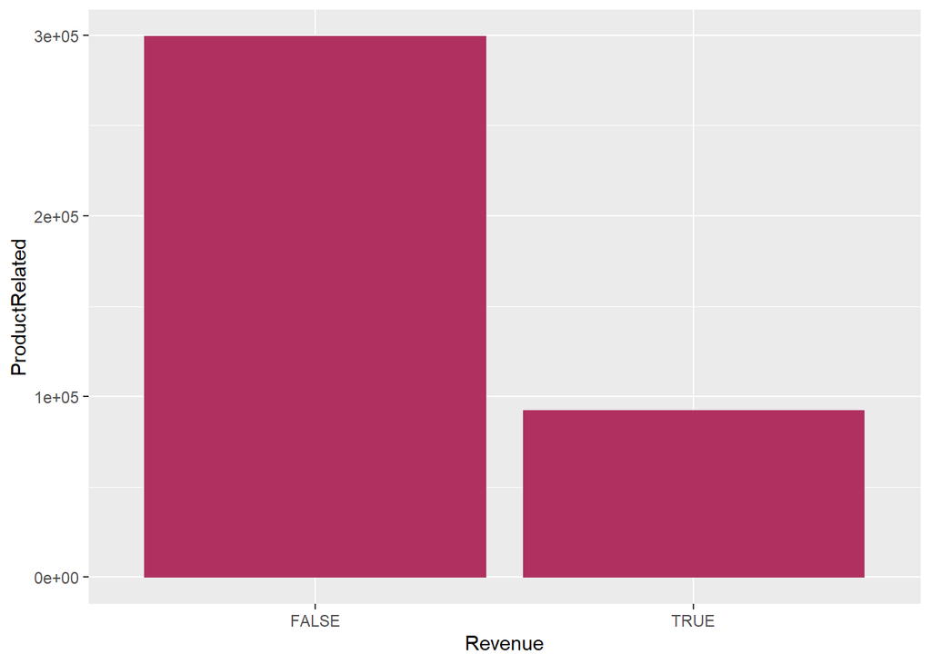

```r
#Bar plot between Revenue and ProductRelated

ggplot(ecommerce, aes(Revenue,ProductRelated )) +
   geom_bar(stat = 'identity',col = "Maroon")+ labs(y="ProductRelated",x="Revenue")
```

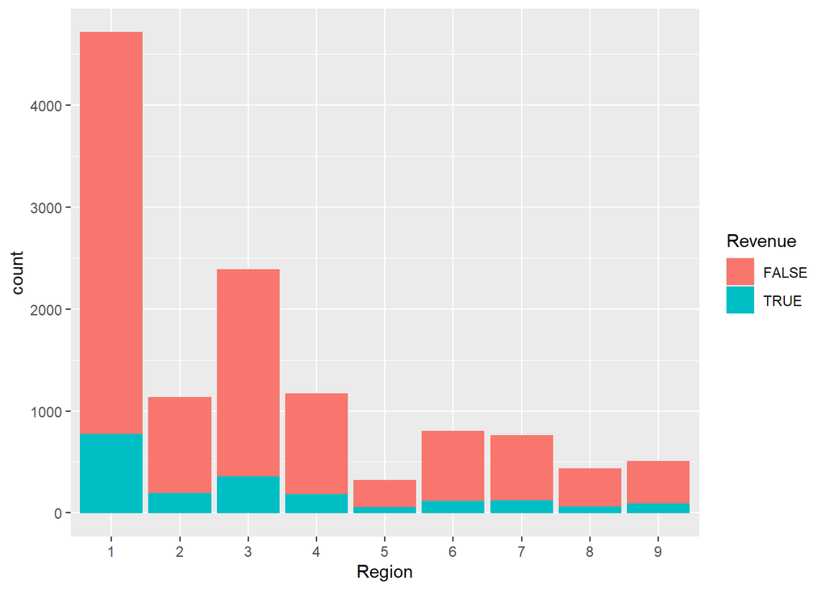

```r
#Bar plot between Revenue and Region

ggplot(ecommerce, aes(Region, fill=Revenue, color=Revenue )) +
   geom_bar(binwidth=1)
```

- Region 1 and 3 were the leading revenue generator.

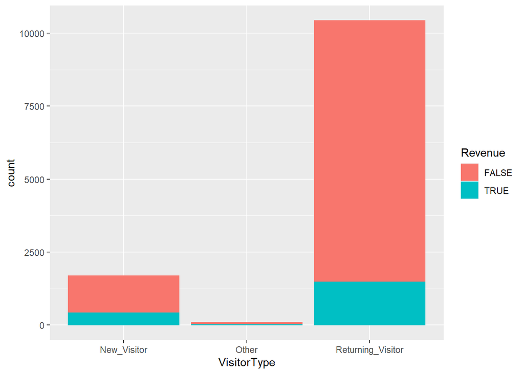

```r
#Bar plot between Revenue and VisitorType

ggplot(ecommerce, aes(VisitorType, fill=Revenue, color=Revenue )) +
   geom_bar(binwidth=1)
```

- Returing users, generated higher revenue compared to new visitos and others.

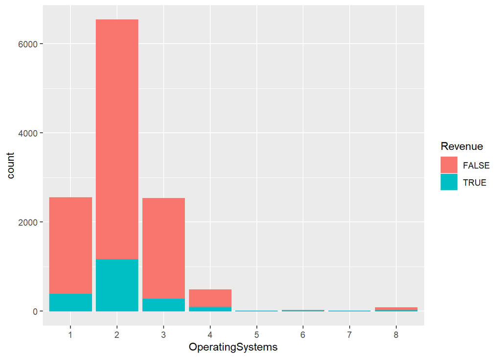

```r
#Bar plot between Revenue and OperatingSystem

ggplot(ecommerce, aes(OperatingSystems, fill=Revenue, color=Revenue )) +
   geom_bar(binwidth=1)
```

- users of Operating system type 2 generated highes income.

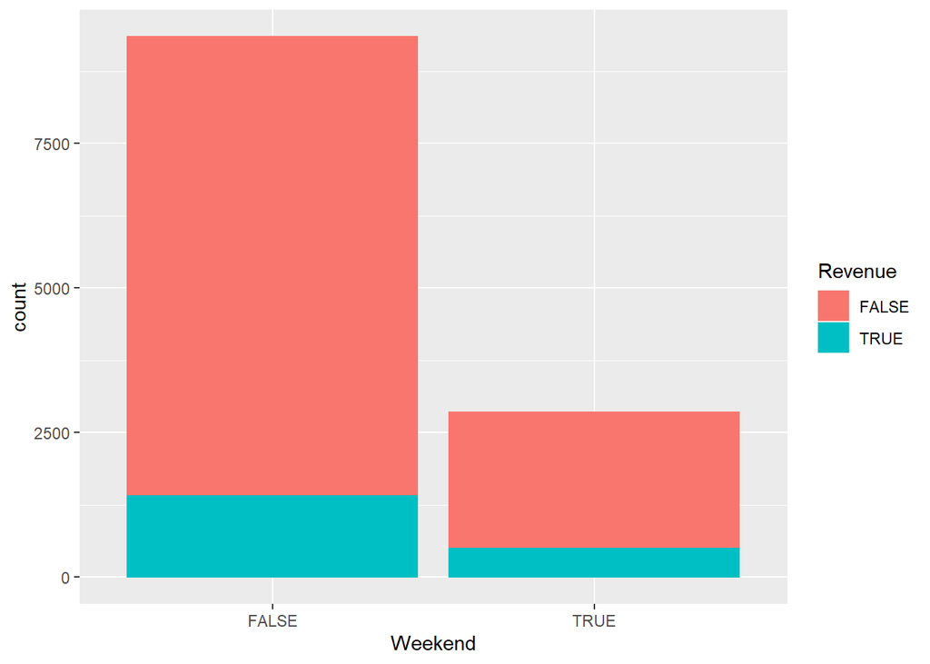

```r
#Bar plot between Revenue and Weekend

ggplot(ecommerce, aes(Weekend, fill=Revenue, color=Revenue )) +
   geom_bar(binwidth=1)
```

- Days that are not weekend generated higher revenue compared to the weekends.

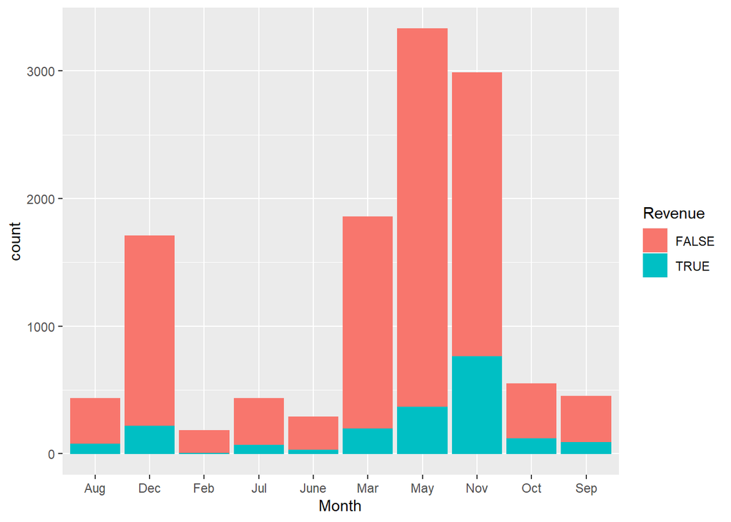

```r
#Bar plot between Revenue and Month

ggplot(ecommerce, aes(Month, fill=Revenue, color=Revenue )) +
   geom_bar(binwidth=1)
```

- The months of November, May and December generated high revenue while February generated least revenue.

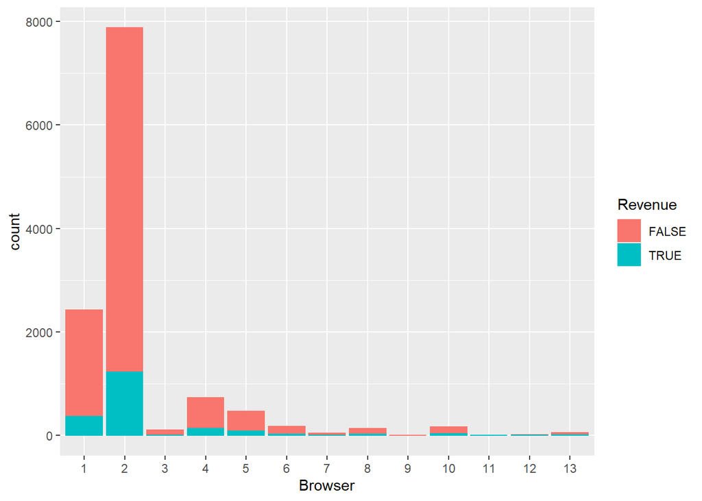

```r
#Bar plot between Revenue and Browser

ggplot(ecommerce, aes(Browser, fill=Revenue, color=Revenue )) +
   geom_bar(binwidth=1)
```

- Browser type 2 and 1 generated significant revenue while browser 9 generated none.

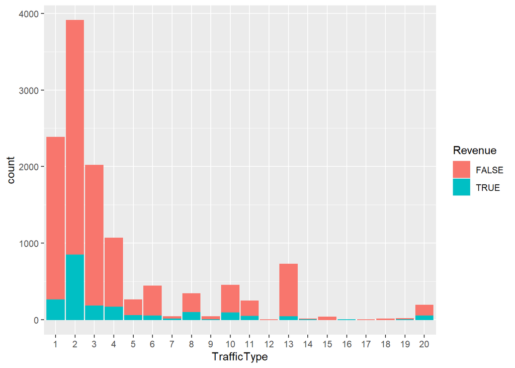

```r
#Bar plot between Revenue and TrafficType

ggplot(ecommerce, aes(TrafficType, fill=Revenue, color=Revenue )) +
   geom_bar(binwidth=1)
```

```r
#Label Encoding
library(superml)
lbl = LabelEncoder$new()

month<-lbl$fit(ecommerce$Month)
ecommerce$Month<-factor(lbl$fit_transform(month))

weekend<-lbl$fit(ecommerce$Weekend)
ecommerce$Weekend<-factor(lbl$fit_transform(weekend))

visitor<-lbl$fit(ecommerce$VisitorType)
ecommerce$VisitorType<-factor(lbl$fit_transform(visitor))
 glimpse(ecommerce)
```

```
## Rows: 12,199
## Columns: 18
## $ Administrative          <int> 0, 0, 0, 0, 0, 0, 0, 1, 0, 0, 0, 0, 0, 0, 0, 2…
## $ Administrative_Duration <dbl> 0, 0, -1, 0, 0, 0, -1, -1, 0, 0, 0, 0, 0, 0, 0…
## $ Informational           <int> 0, 0, 0, 0, 0, 0, 0, 0, 0, 0, 0, 0, 0, 0, 0, 0…
## $ Informational_Duration  <dbl> 0, 0, -1, 0, 0, 0, -1, -1, 0, 0, 0, 0, 0, 0, 0…
## $ ProductRelated          <int> 1, 2, 1, 2, 10, 19, 1, 1, 2, 3, 3, 16, 7, 6, 2…
## $ ProductRelated_Duration <dbl> 0.000000, 64.000000, -1.000000, 2.666667, 627.…
## $ BounceRates             <dbl> 0.200000000, 0.000000000, 0.200000000, 0.05000…
## $ ExitRates               <dbl> 0.200000000, 0.100000000, 0.200000000, 0.14000…
## $ PageValues              <dbl> 0, 0, 0, 0, 0, 0, 0, 0, 0, 0, 0, 0, 0, 0, 0, 0…
## $ SpecialDay              <dbl> 0.0, 0.0, 0.0, 0.0, 0.0, 0.0, 0.4, 0.0, 0.8, 0…
## $ Month                   <fct> 0, 0, 0, 0, 0, 0, 0, 0, 0, 0, 0, 0, 0, 0, 0, 0…
## $ OperatingSystems        <fct> 1, 2, 4, 3, 3, 2, 2, 1, 2, 2, 1, 1, 1, 2, 3, 1…
## $ Browser                 <fct> 1, 2, 1, 2, 3, 2, 4, 2, 2, 4, 1, 1, 1, 5, 2, 1…
## $ Region                  <fct> 1, 1, 9, 2, 1, 1, 3, 1, 2, 1, 3, 4, 1, 1, 3, 9…
## $ TrafficType             <fct> 1, 2, 3, 4, 4, 3, 3, 5, 3, 2, 3, 3, 3, 3, 3, 3…
## $ VisitorType             <fct> 0, 0, 0, 0, 0, 0, 0, 0, 0, 0, 0, 0, 0, 0, 0, 0…
## $ Weekend                 <fct> 0, 0, 0, 0, 0, 0, 0, 0, 0, 0, 0, 0, 0, 0, 0, 0…
## $ Revenue                 <fct> FALSE, FALSE, FALSE, FALSE, FALSE, FALSE, FALS…
```

### Normalizing the data numeric date

```r
#Random selection of 4000 records
ecommerce <- ecommerce[sample(nrow(ecommerce), 4000), ]
```

```r
#Extracting numeric values norder to determine unique values and outliers
numeric_values<- unlist(lapply(ecommerce, is.numeric))

numeric_cols<-ecommerce[,numeric_values]
#Printing the numeric columns
colnames(numeric_cols)
```

```
##  [1] "Administrative"          "Administrative_Duration"
##  [3] "Informational"           "Informational_Duration"
##  [5] "ProductRelated"          "ProductRelated_Duration"
##  [7] "BounceRates"             "ExitRates"
##  [9] "PageValues"              "SpecialDay"
```

```r
ecommerce_Norm <- as.data.frame(scale(numeric_cols))
head(ecommerce_Norm)
```

```
##   Administrative Administrative_Duration Informational Informational_Duration
## 1     -0.7144553             -0.45138000    -0.3938737            -0.24753047
## 2     -0.7144553             -0.45138000    -0.3938737            -0.24753047
## 3      0.1916389              0.06382192    -0.3938737            -0.24753047
## 4     -0.4124239              2.47009232    -0.3938737            -0.24753047
## 5     -0.4124239              0.32659122     2.7445619             0.08552288
## 6      0.1916389             -0.01832749    -0.3938737            -0.24753047
##   ProductRelated ProductRelated_Duration BounceRates  ExitRates PageValues
## 1     0.41335408           -0.0001953759  -0.4533242 -0.6349398  0.1909501
## 2    -0.66740908           -0.5559919363   3.8133017  3.3367119 -0.3218678
## 3    -0.25671908           -0.3888424626  -0.2593867 -0.7949219 -0.3218678
## 4    -0.38641066            0.0747794330  -0.4533242 -0.2405882  0.2104402
## 5    -0.34318013           -0.4038271770  -0.4533242 -0.8205445 -0.3218678
## 6    -0.08379697           -0.2698290499  -0.3009447 -0.7173680 -0.3218678
##   SpecialDay
## 1 -0.3164642
## 2 -0.3164642
## 3 -0.3164642
## 4 -0.3164642
## 5 -0.3164642
## 6 -0.3164642
```

```r
set.seed(240)

ecommerce_k2 <- kmeans(ecommerce_Norm, centers = 2, nstart = 25)
ecommerce_k3 <- kmeans(ecommerce_Norm, centers = 3, nstart = 25)
ecommerce_k4 <- kmeans(ecommerce_Norm, centers = 4, nstart = 25)
ecommerce_k5 <- kmeans(ecommerce_Norm, centers = 5, nstart = 25)
ecommerce_k6 <- kmeans(ecommerce_Norm, centers = 6, nstart = 25)
```

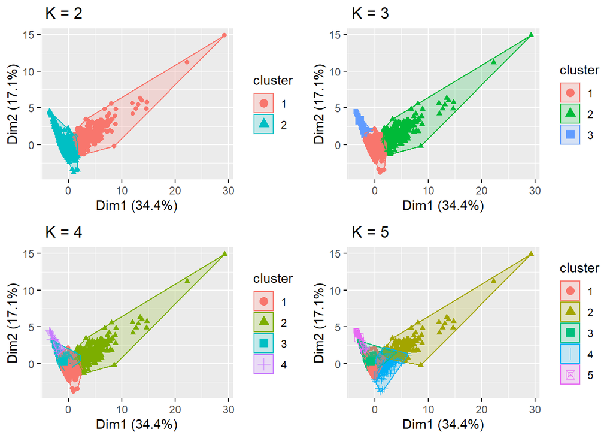

```r
p1 <- fviz_cluster(ecommerce_k2, geom = "point", data = ecommerce_Norm) + ggtitle(" K = 2")
p2 <- fviz_cluster(ecommerce_k3, geom = "point", data = ecommerce_Norm) + ggtitle(" K = 3")
p3 <- fviz_cluster(ecommerce_k4, geom = "point", data = ecommerce_Norm) + ggtitle(" K = 4")
p4 <- fviz_cluster(ecommerce_k5, geom = "point", data = ecommerce_Norm) + ggtitle(" K = 5")
p5 <- fviz_cluster(ecommerce_k6, geom = "point", data = ecommerce_Norm) + ggtitle(" K = 6")
grid.arrange(p1, p2, p3, p4, nrow = 2)
```

### Determining Optimal Cluster

### Elbow method

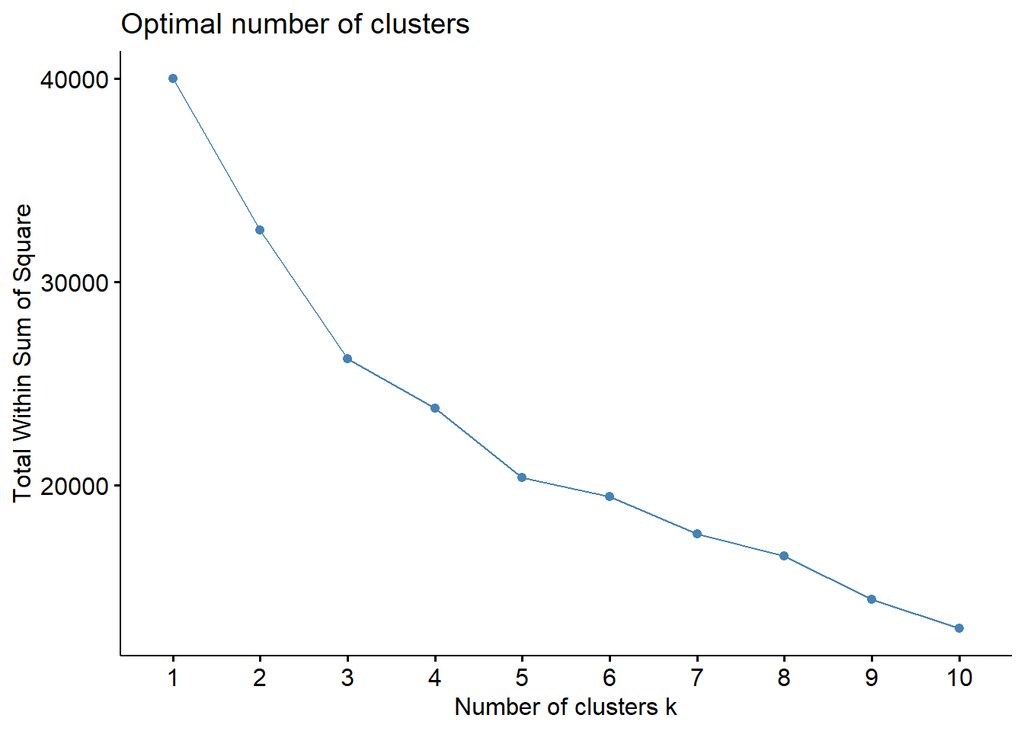

```r
fviz_nbclust(x= ecommerce_Norm, FUNcluster = kmeans, method ='wss' )
```

### Silhouette Method

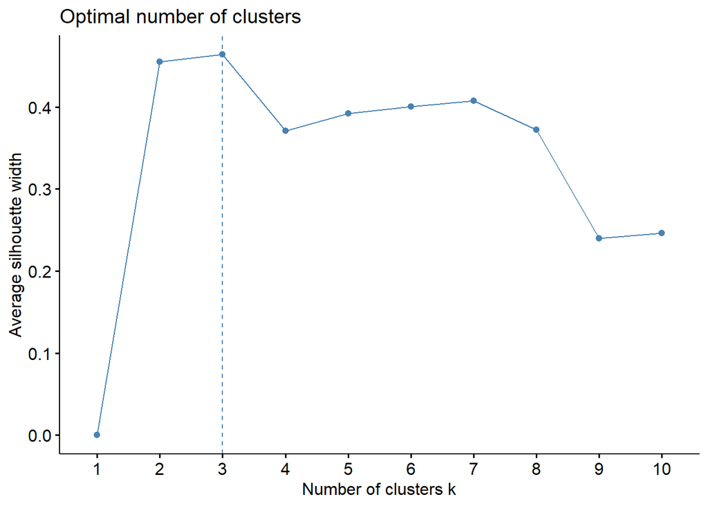

```r
fviz_nbclust(x= ecommerce_Norm, FUNcluster = kmeans, method ='silhouette' )
```

```r
#set.seed(204)
#gap_stat <- clusGap(x = ecommerce_Norm, FUN = kmeans, K.max = 15, nstart = 25, B = 50,iter.max=35)

# plot the result to determine the optimal number of clusters.
#fviz_gap_stat(gap_stat)
```

### Aplying optimum k value

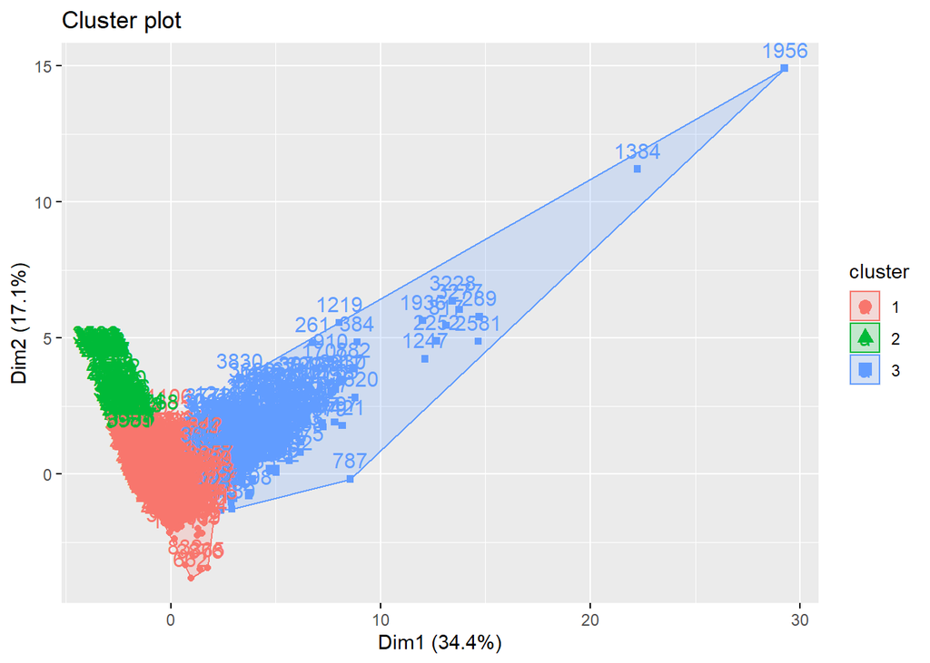

```r
#Apply k=3
set.seed(204)
ecomerce_final <- kmeans(ecommerce_Norm, centers = 3,nstart = 25)
fviz_cluster(ecomerce_final, data =ecommerce_Norm )
```

### Printing out the centers

```r
ecomerce_final$centers
```

```
##   Administrative Administrative_Duration Informational Informational_Duration
## 1     -0.1420533              -0.1350533    -0.1992289             -0.1796561
## 2     -0.6943836              -0.4421291    -0.3913907             -0.2469991
## 3      1.5812638               1.3434829     1.7906523              1.5370603
##   ProductRelated ProductRelated_Duration BounceRates  ExitRates   PageValues
## 1     -0.1601448              -0.1478034  -0.2602622 -0.2210367 -0.002366835
## 2     -0.6252046              -0.5256245   3.1028246  2.9217817 -0.321867798
## 3      1.6670895               1.5009319  -0.3105791 -0.4738997  0.253850438
##    SpecialDay
## 1  0.00197361
## 2  0.22320343
## 3 -0.17854394
```

### Printing the summary of the model

```r
print(ecomerce_final)
```

```
## K-means clustering with 3 clusters of sizes 3253, 316, 431
##
## Cluster means:
##   Administrative Administrative_Duration Informational Informational_Duration
## 1     -0.1420533              -0.1350533    -0.1992289             -0.1796561
## 2     -0.6943836              -0.4421291    -0.3913907             -0.2469991
## 3      1.5812638               1.3434829     1.7906523              1.5370603
##   ProductRelated ProductRelated_Duration BounceRates  ExitRates   PageValues
## 1     -0.1601448              -0.1478034  -0.2602622 -0.2210367 -0.002366835
## 2     -0.6252046              -0.5256245   3.1028246  2.9217817 -0.321867798
## 3      1.6670895               1.5009319  -0.3105791 -0.4738997  0.253850438
##    SpecialDay
## 1  0.00197361
## 2  0.22320343
## 3 -0.17854394
```

[output cut: 120 more lines]

## Hierachical Clustering

### Divisive Clustering

```r
#Computing divisive hierarchical clustering
hc <- diana(ecommerce)
#Cutting the diana() tree into 4 using cutree
cutree(as.hclust(hc),k=4)
```

[output not shown]

[output cut: 94 more lines]

```r
#Amount of clustering found
hc$dc
```

```
## [1] 0.9989935
```

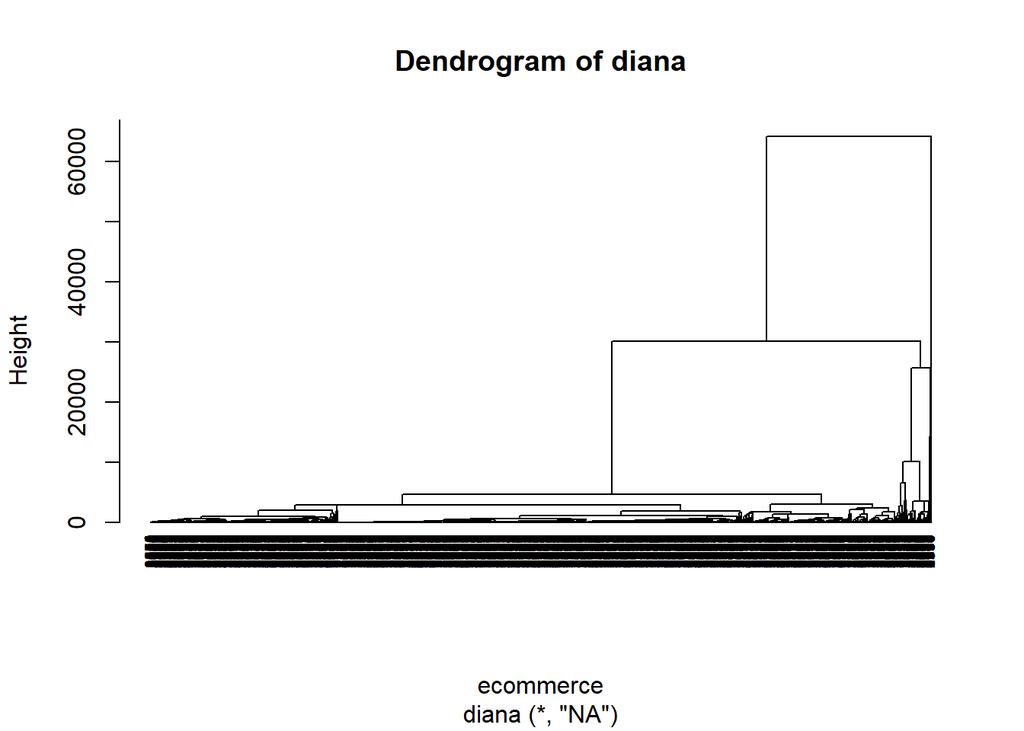

```r
pltree(hc, cex = 0.6, hang = -1, main = "Dendrogram of diana")
```

### Determining the optimal clusters

### Elbow Method

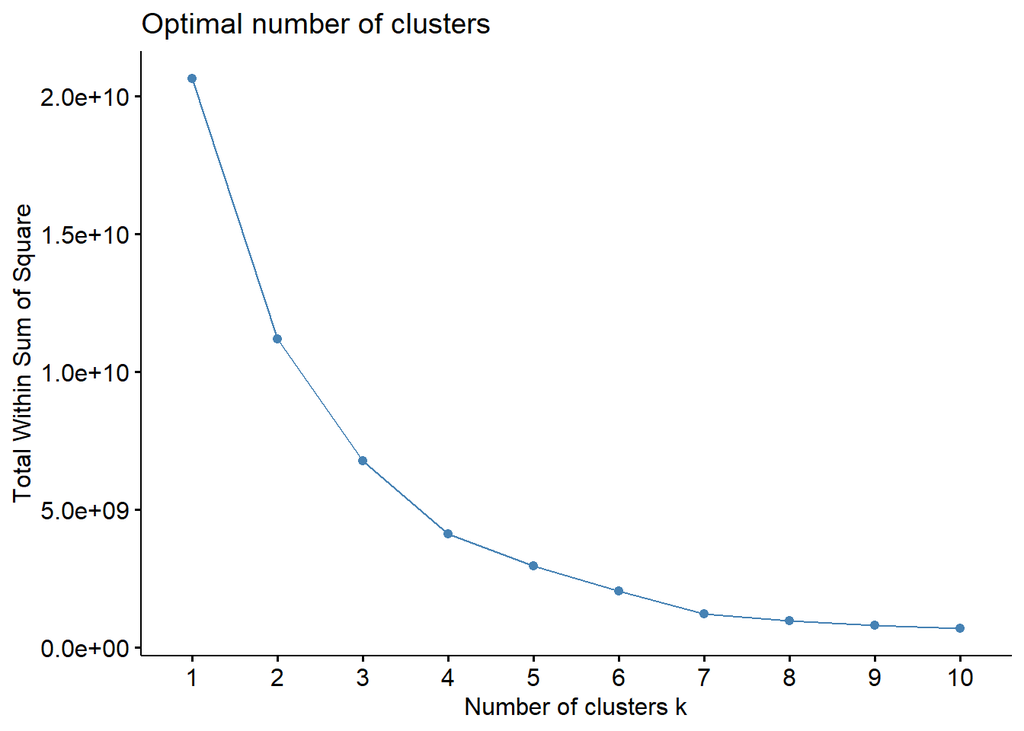

```r
fviz_nbclust(ecommerce, FUN = hcut, method = "wss")
```

### Silhout Method

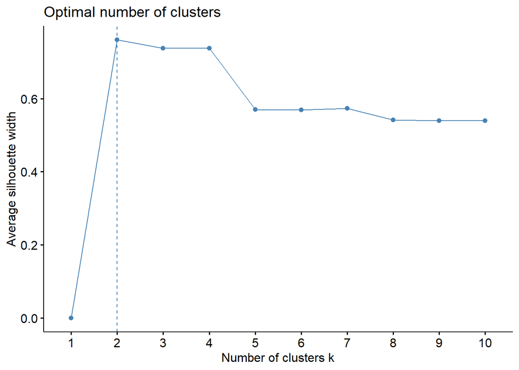

```r
fviz_nbclust(ecommerce, FUN = hcut, method = "silhouette")
```

### Gap Statistic Method

```r
#gap_stat <- clusGap(ecommerce_Norm, FUN = hcut, nstart = 25, K.max = 10, B = 50)
#fviz_gap_stat(gap_stat)
```

Due to low computational power, I terminated the excecution process

## Conclusion

- Hierarchical clusterng works better than kmeans clustering